# A2_CSE_512

### Exploring the qm7b dataset

The qm7 dataset is a subset of GDB-13 (a database of nearly 1 billion stable and synthetically accessible organic molecules) composed of all molecules of up to 23 atoms (including 7 heavy atoms C, N, O, and S), totalling 7165 molecules. the molecues are represented by Couloumb matrix and their atomization energies are computed similarly to the FHI-AIMS implementation of the Perdew-Burke-Ernzehrof hybrid functional (PBEO). This dataset features a large variety of molecular structures such as double and triple bonds, cycles, carboxy, cyanide, amide, alcohol and epoxy. It is composed of three multi-dimenesional arrays X (7165 x 23 x 23), T (7165) and P (5 x 1433) representing the inputs (Coulomb matrices), the labels (atomization energies) and the splits for cross-validation, respectively. The dataset also contain two additional multi-dimensional arrays Z (7165) and R (7165 x) representing the atomic charge and the cartesian coordinate of each atom in the molecules.

The qm7b dataset is an extension of the qm7 dataset for multitask learning where 13 additional properties (e.g. polarizability, HOMO and LUMO eigen-values, excitation energies) have to be predicted at different levels of theory (ZINDO, SCS, PBEO, GW). Additional molecules comprising chlorine atoms are also included, totalling 7211 molecules. It is composed of two multi-dimensional arrays x (7211 x 23 x 23) and T (7211 X 14) representing the inputs (Coulomb matrices) and the labels (molecular properties) and one array names of size 14 listing the names of the different properties.

### Analysis Questions

```python
#@title
import numpy as np
import pandas as pd

import qcportal as ptl

client = ptl.FractalClient(address="api.qcarchive.molssi.org")
client
```

```python
#@title
!pip install qcportal
```

```python
#@title
import numpy as np
import pandas as pd
import matplotlib.pyplot as plt
import scipy.stats
from mpl_toolkits import mplot3d
from scipy.stats import norm
from scipy.stats import mode
from mpl_toolkits.mplot3d import Axes3D
%matplotlib inline
```

```python
#@title
df = pd.read_csv('http://faculty.washington.edu/tingcao/wordpress/wp-content/uploads/2020/10/qm7b.csv')
```

```python
#@title
df.head()
```

|  | id | ae_pbe0 | emax_zindo | imax_zindo | homo_zindo | lumo_zindo | e1_zindo | ip_zindo | ea_zindo | homo_pbe0 | lumo_pbe0 | homo_gw | lumo_gw | p_pbe0 | p_scs | n_H | n_C | n_N | n_O | n_S | n_Cl |
| --- | --- | --- | --- | --- | --- | --- | --- | --- | --- | --- | --- | --- | --- | --- | --- | --- | --- | --- | --- | --- | --- |
| 0 | 1 | -420.933746 | 39.694626 | 0.621841 | -16.013 | 4.162 | 36.768073 | 15.72523 | -3.98613 | -10.9488 | 0.1323 | -14.1341 | 1.0870 | 2.534576 | 2.43222 | 4 | 1 | 0 | 0 | 0 | 0 |
| 1 | 2 | -718.419189 | 22.622486 | 0.628328 | -13.549 | 3.684 | 11.717433 | 13.41121 | -3.49181 | -9.5577 | 0.1452 | -12.5472 | 1.1186 | 4.332028 | 4.44500 | 6 | 2 | 0 | 0 | 0 | 0 |
| 2 | 3 | -570.024841 | 22.940671 | 0.709060 | -10.160 | 1.231 | 7.137266 | 9.75211 | -0.82042 | -7.8768 | -0.0620 | -10.4383 | 1.9456 | 4.173282 | 3.92308 | 4 | 2 | 0 | 0 | 0 | 0 |
| 3 | 4 | -410.286163 | 15.973798 | 2.228480 | -10.706 | 2.145 | 4.624107 | 10.46577 | -1.89847 | -8.4021 | 0.4143 | -11.1629 | 1.1958 | 3.512394 | 3.32175 | 2 | 2 | 0 | 0 | 0 | 0 |
| 4 | 5 | -868.855408 | 17.900516 | 0.556174 | -12.365 | 3.825 | 10.311655 | 11.96491 | -3.57487 | -8.3534 | 0.2690 | -10.8132 | 1.2002 | 5.480160 | 5.78632 | 6 | 3 | 0 | 0 | 0 | 0 |

```python
#@title
df.keys()
```

```
Index(['id', 'ae_pbe0', 'emax_zindo', 'imax_zindo', 'homo_zindo', 'lumo_zindo',
       'e1_zindo', 'ip_zindo', 'ea_zindo', 'homo_pbe0', 'lumo_pbe0', 'homo_gw',
       'lumo_gw', 'p_pbe0', 'p_scs', 'n_H', 'n_C', 'n_N', 'n_O', 'n_S',
       'n_Cl'],
      dtype='object')
```

[output not shown]

dataset shape

```python
#@title
df.shape
```

```
(7211, 21)
```

```python
#@title
from IPython.display import Image
Image(url='https://upload.wikimedia.org/wikipedia/commons/thumb/7/7b/Molecule_HOMO-LUMO_diagram.svg/1200px-Molecule_HOMO-LUMO_diagram.svg.png',width = 400, height = 500)
```

[figure not shown]

HOMO, or the *Highest Occupied Molecular Orbital*, describes the highest energy level occupied by electrons in the ground state of a molecule. The LUMO, or the *Lowest Unoccupied Molecular Orbital*, then describes the lowest unoccupied energy level which excited electrons from the HOMO often enter.

1. Let's explore the data a little, make some sense of this incomprehensible jumble of numbers, and observe how the three HOMO and LUMO measurements look relative to each other. This allows us to appreciate and get an initial feel for the data. The three values are calculated with different simulation techniques, ZINDO, GW, and DFT/PBEO.

```python
#@title Line of code
HOMOs = df[['homo_pbe0','homo_gw','homo_zindo']]
```

And now we observe how `homo_pbe0` and `homo_gw` are correlated, where the colors of the datapoints are varied with `homo-zindo`

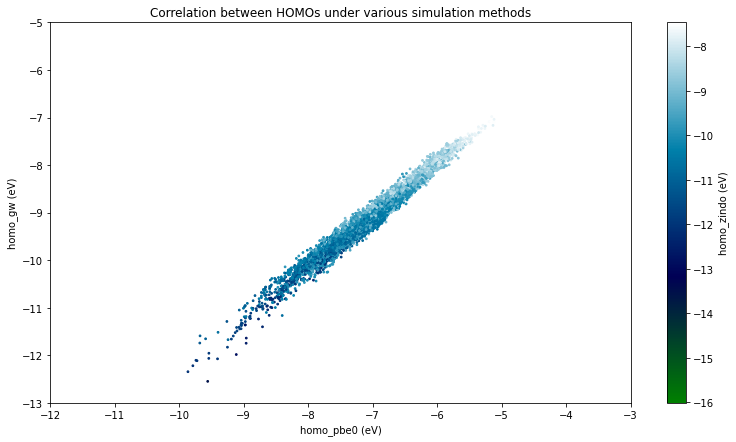

```python
#@title
fig = plt.figure(figsize=(13,7))
plt.scatter(HOMOs['homo_pbe0'], HOMOs['homo_gw'], s=3, c=HOMOs['homo_zindo'], cmap='ocean')
plt.colorbar(label='homo_zindo (eV)')
plt.xlim(-12,-3)
plt.ylim(-13,-5)
plt.title('Correlation between HOMOs under various simulation methods')
plt.xlabel('homo_pbe0 (eV)')
plt.ylabel('homo_gw (eV)')
```

And now we observe how `homo_pbe0` and `homo_zindo` are correlated, where the colors of the datapoints are varied with `homo-gw`

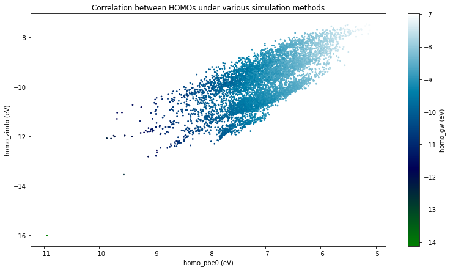

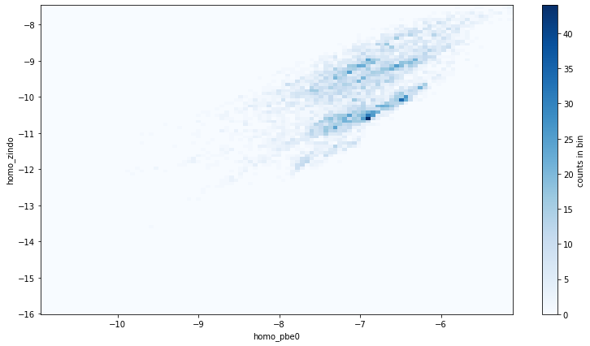

```python
#@title
fig = plt.figure(figsize=(13,7))
plt.scatter(HOMOs['homo_pbe0'], HOMOs['homo_zindo'], s=3, c=HOMOs['homo_gw'],cmap='ocean')
plt.colorbar(label='homo_gw (eV)')
#plt.xlim(-14,-5)
#plt.ylim(-14,-5)
plt.title('Correlation between HOMOs under various simulation methods')
plt.xlabel('homo_pbe0 (eV)')
plt.ylabel('homo_zindo (eV)')

plt.figure(figsize=(13,7))
plt.hist2d(HOMOs['homo_pbe0'], HOMOs['homo_zindo'], bins=100, cmap='Blues')
plt.colorbar(label='counts in bin')
plt.xlabel('homo_pbe0')
plt.ylabel('homo_zindo')
```

Finally, let's observe how `homo_gw` and `homo_zindo` are correlated, where the colors of the datapoints are varied with `homo-pbe0`

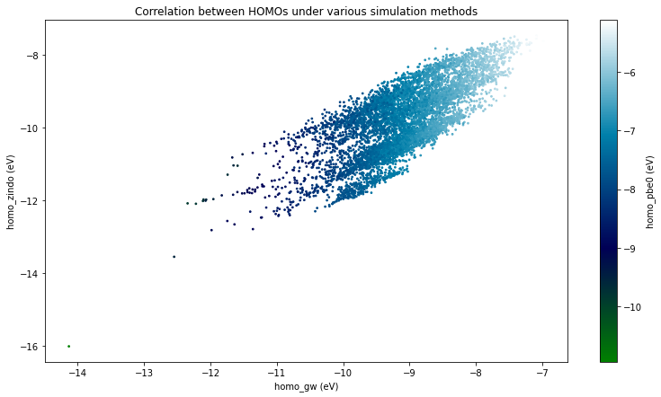

```python
#@title
fig = plt.figure(figsize=(13,7))
plt.scatter(HOMOs['homo_gw'], HOMOs['homo_zindo'], s=3, c=HOMOs['homo_pbe0'], cmap='ocean')
plt.colorbar(label='homo_pbe0 (eV)')
#plt.xlim(-14,-5)
#plt.ylim(-14,-5)
plt.title('Correlation between HOMOs under various simulation methods')
plt.xlabel('homo_gw (eV)')
plt.ylabel('homo_zindo (eV)')
```

let's look at how the three values look together on a 3D plot!

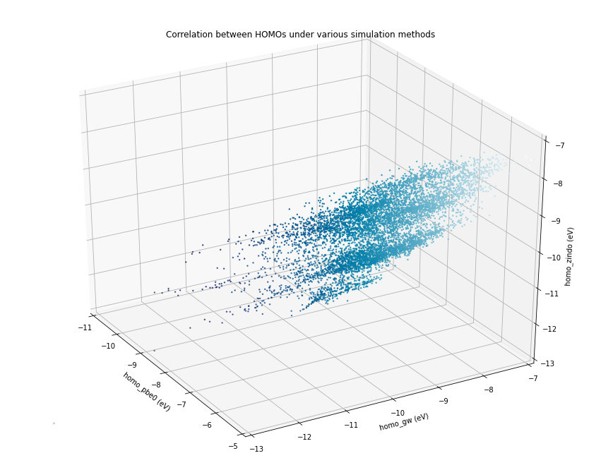

```python
#@title
plt.figure(figsize=(15,12))
ax = plt.axes(projection = '3d', zlim = [-13,-7], xlim = [-11,-5], ylim = [-13,-7])
HOMO3d=ax.scatter3D(HOMOs['homo_pbe0'], HOMOs['homo_gw'], HOMOs['homo_zindo'], s=2, c=HOMOs['homo_gw'], cmap='ocean')
#cbar=plt.colorbar(HOMO3d, shrink=0.5)
#cbar.set_label('homo_gw')

ax.view_init(30,-30)
ax.set_xlabel('homo_pbe0 (eV)')
ax.set_ylabel('homo_gw (eV)')
ax.set_zlabel('homo_zindo (eV)')
ax.set_title('Correlation between HOMOs under various simulation methods')
```

### Now on to LUMOs

```python
#@title
LUMOs = df[['lumo_pbe0','lumo_gw','lumo_zindo']]
```

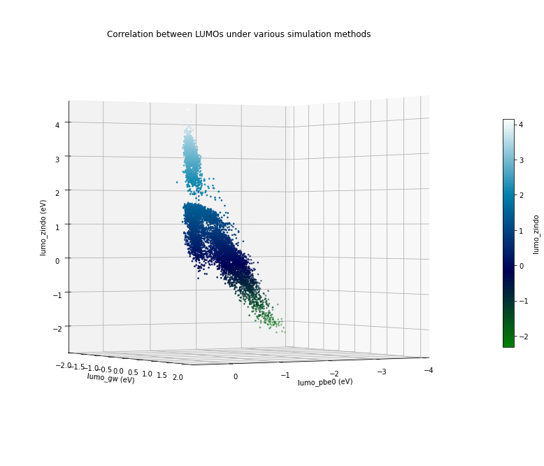

```python
#@title
fig = plt.figure(figsize=(15,12))
ax = plt.axes(projection='3d')
HOMO3d=ax.scatter3D(LUMOs['lumo_pbe0'], LUMOs['lumo_gw'], LUMOs['lumo_zindo'], s=3, c=LUMOs['lumo_zindo'], cmap='ocean')
cbar=plt.colorbar(HOMO3d,shrink=0.5)
cbar.set_label('lumo_zindo')

ax.view_init(0,60)
ax.set_xlabel('lumo_pbe0 (eV)')
ax.set_ylabel('lumo_gw (eV)')
ax.set_zlabel('lumo_zindo (eV)')
ax.set_title('Correlation between LUMOs under various simulation methods')
```

### Ionization Potential, Electron Affinity, and Atomization Energy

1. *Ionization potential* describes the minimum energy required to remove the most loosely bound electron from a neutral atom or molecule.*Electron affinity* describes the energy released when an electron is attached to a neutral atom or molecule. One would, therefore, expect some level of correlation between the two. Let's look at how they are also related to Atomization Energy, which measures the energy it would take to break down a molecule into all its individual atoms. Let's plot some initial, non-judgmental visuals to get a feel for the data again:

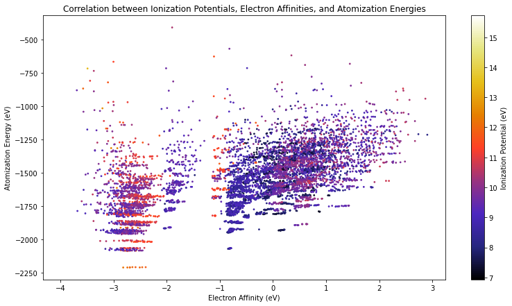

```python
#@title
plt.figure(figsize=(13,7))
plt.scatter(df['ea_zindo'], df['ae_pbe0'], s=3, c=df['ip_zindo'], cmap='CMRmap')
plt.colorbar(label='Ionization Potential (eV)')
plt.title('Correlation between Ionization Potentials, Electron Affinities, and Atomization Energies')
plt.xlabel('Electron Affinity (eV)')
plt.ylabel('Atomization Energy (eV)')
```

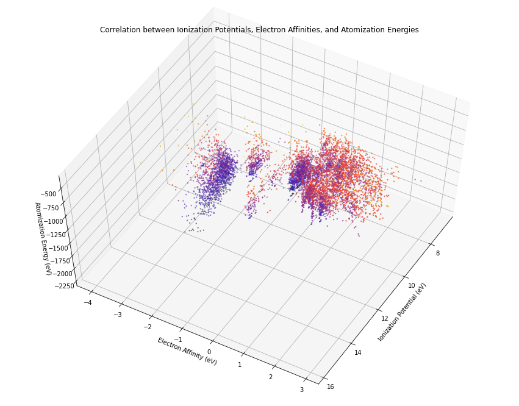

```python
#@title
fig = plt.figure(figsize=(15,12))
ax = plt.axes(projection='3d')
HOMO3d=ax.scatter3D(qm7b['ip_zindo'], qm7b['ea_zindo'], qm7b['ae_pbe0'], s=2, c=qm7b['ae_pbe0'], cmap='CMRmap')
plt.xlabel('X')
plt.ylabel('Y')
#plt.zlabel('Z')
#cbar=plt.colorbar(HOMO3d,shrink=0.5, label = "Atomization Energy (eV)")
ax.view_init(60,30)
ax.set_xlabel('Ionization Potential (eV)')
ax.set_ylabel('Electron Affinity (eV)')
ax.set_zlabel('Atomization Energy (eV)')
ax.set_title('Correlation between Ionization Potentials, Electron Affinities, and Atomization Energies')
```

1. Let's observe how the number of carbons in a given molecule, `n_C`, is correlated with the atomization energy of the molecule, `ae_pbe0`

```python
#@title
n_C_ae = qm7b[['n_C','ae_pbe0']]
```

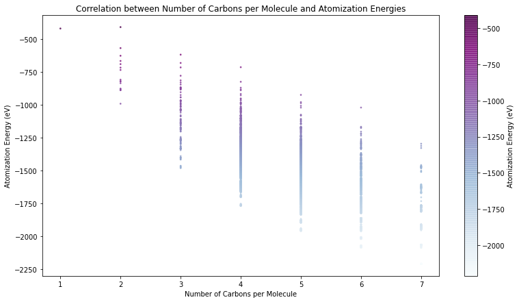

```python
#@title
plt.figure(figsize=(13,7))
plt.scatter(qm7b['n_C'], qm7b['ae_pbe0'], s=3, c=qm7b['ae_pbe0'], cmap='BuPu', alpha =0.7)
plt.colorbar(label='Atomization Energy (eV)')
plt.title('Correlation between Number of Carbons per Molecule and Atomization Energies')
plt.xlabel('Number of Carbons per Molecule')
plt.ylabel('Atomization Energy (eV)')
```

The more carbons per molecule, the more negative the atomization energy becomes. This is because more energy needs to be taken to break the increasingly large molecules into its constituent atoms.

1. how does the normal distribution of homo_gw in the dataset look like

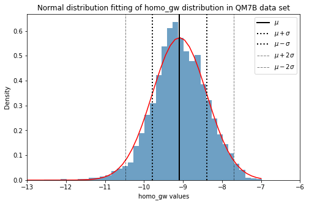

```python
#@title
plt.figure(figsize=(8,5))
ax = plt.axes()
x = np.linspace(-13,-7);
#loc specifies the center of the distribution, while scale specifies the standard deviation
y = norm(loc = -9.091136194702537, scale = 0.6958487451104021).pdf(x);
ax.plot(x, y, color='red');
ax.hist(qm7b['homo_gw'], density = True, bins=50, color='#4A88B6', alpha=0.8);
plt.axvline(HOMOs['homo_gw'].mean(), color='k', linestyle='solid', linewidth=2, label = '$\mu$')
plt.axvline(HOMOs['homo_gw'].mean()+np.std(HOMOs['homo_gw']), color='k', linestyle='dotted', linewidth=2, label = '$\mu+\sigma$')
plt.axvline(HOMOs['homo_gw'].mean()-np.std(HOMOs['homo_gw']), color='k', linestyle='dotted', linewidth=2, label = '$\mu-\sigma$')
plt.axvline(HOMOs['homo_gw'].mean()+2*np.std(HOMOs['homo_gw']), color='k', linestyle='dashed', linewidth=1, label = '$\mu+2\sigma$',alpha=0.5)
plt.axvline(HOMOs['homo_gw'].mean()-2*np.std(HOMOs['homo_gw']), color='k', linestyle='dashed', linewidth=1, label = '$\mu-2\sigma$',alpha=0.5)
plt.legend()
plt.xlim(-13,-6)
plt.ylabel('Density')
plt.xlabel('homo_gw values')
plt.title("Normal distribution fitting of homo_gw distribution in QM7B data set")
```

It's important to note that roughly:

- 68.2% of data falls within 1 standard deviation from the mean (from $\mu-\sigma$ to $\mu+\sigma$)
- 95.4% of data falls within 2 s.d's from the mean (from $\mu-2\sigma$ to $\mu+2\sigma$)
- 99.7% of data falls within 3 s.d's from the mean (from $\mu-3\sigma$ to $\mu+3\sigma$)

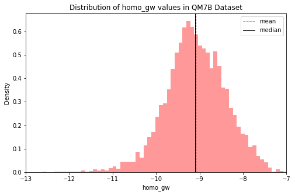

```python
#@title
plt.figure(figsize=(8,5))
plt.hist(df['homo_gw'], color='r', bins=80, alpha = 0.4, density=True);
plt.axvline(df['homo_gw'].mean(), color='k', linestyle='dashed', linewidth=1, label = 'mean')
plt.axvline(df['homo_gw'].median(), color='k', linestyle='solid', linewidth=1, label = 'median')
plt.xlim(-13,-7)
plt.ylabel('Density')
plt.xlabel('homo_gw')
plt.title('Distribution of homo_gw values in QM7B Dataset')
plt.legend()
```

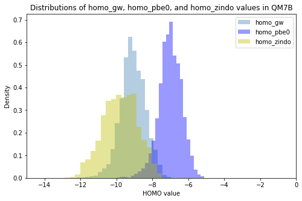

```python
#@title
plt.figure(figsize=(8,5))
plt.hist(HOMOs['homo_gw'], color = 'steelblue', bins=30, alpha = 0.4, density=True, label='homo_gw')
plt.hist(HOMOs['homo_pbe0'], color='b', bins=30, alpha = 0.4, density=True, label='homo_pbe0')
plt.hist(HOMOs['homo_zindo'], color='y', bins=30, alpha = 0.4, density=True, label='homo_zindo')
plt.legend()
plt.xlim(-15,0)
plt.ylabel('Density')
plt.xlabel('HOMO value')
plt.title('Distributions of homo_gw, homo_pbe0, and homo_zindo values in QM7B')
```

Cumulative density of homo_gw values

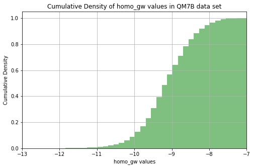

```python
#@title
plt.figure(figsize=(8,5))
qm7b['homo_gw'].hist(density = True, cumulative=True, bins = 50, color ='g', alpha=0.5)
plt.xlim(-13,-7)
plt.ylabel('Cumulative Density')
plt.xlabel('homo_gw values')
plt.title("Cumulative Density of homo_gw values in QM7B data set");
```